# Decision Tree Agustus 2025

Kode ringkas dan jawaban soal (a)–(d): Risiko Mobil

2026-10-07

Simpan file di working directory R dengan nama aslinya, `data_soal 2_mobil.csv`, agar kode baca data di bawah langsung jalan.

Data soal Agustus 2025 (CSV) · 30 KB

**Cara menjalankan:** letakkan Rmd dan

```
data_soal
2_mobil.csv
```

dalam folder yang sama, buka di RStudio, lalu klik **Knit**. Bagian 1 melatih pohon sederhana dengan `rpart`. Bagian 2 menjawab soal menggunakan aturan pada gambar dan data CSV.

# 1. Kode minimum untuk membuat decision tree

## 1.1. Library dan baca data

Instalasi cukup sekali di Console jika paket belum tersedia.

```r
install.packages(c("rpart", "rpart.plot", "caret", "rmarkdown"))
```

```r
library(rpart)
library(rpart.plot)
library(caret)
```

```r
data <- read.csv2("data_soal 2_mobil.csv", stringsAsFactors = FALSE)
data <- data[, c("Peringkat_risiko", "Perusahaan_mobil", "Berat_mobil",
                 "Jarak_tempuh", "horsepower")]

data$Risiko <- factor(ifelse(data$Peringkat_risiko > 0, 1, 0),
                       levels = c(0, 1),
                       labels = c("Tidak berisiko", "Berisiko"))
data$Peringkat_risiko <- NULL
data$Perusahaan_mobil <- factor(data$Perusahaan_mobil)

table(data$Risiko)
```

```
##
## Tidak berisiko       Berisiko
##             92            113
```

```r
prop.table(table(data$Risiko))
```

```
##
## Tidak berisiko       Berisiko
##      0.4487805      0.5512195
```

**Definisi sesuai soal:** peringkat risiko positif masuk kelas **1 = Berisiko**. Peringkat nol atau negatif masuk kelas **0 = Tidak berisiko**. `Peringkat_risiko` dihapus setelah membuat target agar tidak menjadi prediktor yang membocorkan jawaban.

`read.csv2()` sesuai untuk CSV ini karena pemisah kolomnya titik koma. Agar kode tetap minimum, model hanya memakai **empat prediktor yang muncul pada gambar soal**: perusahaan mobil, berat mobil, jarak tempuh, dan horsepower. Keempat kolom tersebut tidak memiliki nilai kosong dan ketiga prediktor numeriknya terbaca sebagai angka. Kolom lain pada CSV tidak digunakan.

Data berisi **205 mobil**, terdiri dari **92 tidak berisiko (44,88%)** dan **113 berisiko (55,12%)**. Kedua kelas relatif seimbang sehingga undersampling tidak diperlukan untuk latihan ini.

## 1.2. Model dan gambar pohon

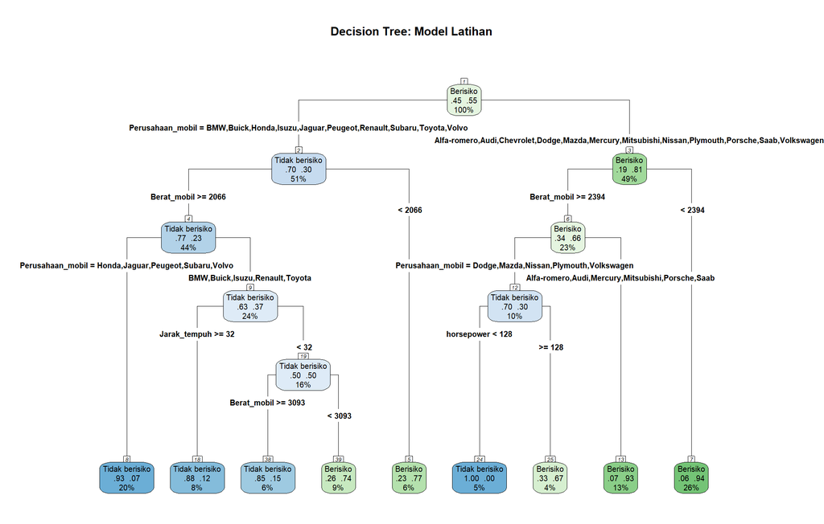

```r
model <- rpart(Risiko ~ ., data = data, method = "class")
rpart.plot(model, type = 4, extra = 104, nn = TRUE,
           fallen.leaves = TRUE, main = "Decision Tree: Model Latihan")
```

`method = "class"` membuat pohon klasifikasi. Parameter lain memakai default agar kode mudah dihafalkan. `nn = TRUE` menampilkan nomor node. `extra = 104` menampilkan proporsi kedua kelas dan persentase observasi pada node.

Dalam setiap kotak, urutannya adalah **kelas prediksi**, proporsi **Tidak berisiko lalu Berisiko**, dan persentase observasi yang masuk ke node. Pada gambar soal, label kelas memakai angka 0 dan 1; grafik latihan memakai nama kelas agar lebih mudah dibaca.

**Batas interpretasi:** kode ini melatih ulang model menggunakan empat prediktor dari gambar. Parameter, prediktor awal, dan proses pembentukan model asli tidak dijelaskan dalam PPT, sehingga struktur hasil latihan tidak dijamin identik. Jawaban angka pada bagian 2 dihitung langsung dari aturan gambar, bukan diasumsikan sama dengan hasil pelatihan ulang.

## 1.3. Evaluasi model latihan

```r
pred <- predict(model, data, type = "class")
cm <- confusionMatrix(pred, data$Risiko,
                       positive = "Tidak berisiko", mode = "everything")
cm
```

```
## Confusion Matrix and Statistics
##
##                 Reference
## Prediction       Tidak berisiko Berisiko
##   Tidak berisiko             76        7
##   Berisiko                   16      106
##
##                Accuracy : 0.8878
##                  95% CI : (0.8364, 0.9275)
##     No Information Rate : 0.5512
##     P-Value [Acc > NIR] : < 2e-16
##
##                   Kappa : 0.7711
##
##  Mcnemar's Test P-Value : 0.09529
##
##             Sensitivity : 0.8261
##             Specificity : 0.9381
##          Pos Pred Value : 0.9157
##          Neg Pred Value : 0.8689
##               Precision : 0.9157
##                  Recall : 0.8261
##                      F1 : 0.8686
##              Prevalence : 0.4488
##          Detection Rate : 0.3707
##    Detection Prevalence : 0.4049
##       Balanced Accuracy : 0.8821
##
##        'Positive' Class : Tidak berisiko
##
```

`positive = "Tidak berisiko"` dipilih karena bagian (d) meminta **precision kelas tidak berisiko**. Lihat `Precision` pada output. Kelas positif berarti kelas yang sedang menjadi fokus evaluasi; tidak harus selalu berarti kelas berisiko.

**Ini evaluasi pada data yang dipakai melatih model.** Angkanya mengukur kecocokan pada data tersebut, bukan performa pada data baru. Untuk mengukur generalisasi, gunakan data testing terpisah atau cross-validation. Split tidak ditambahkan di sini karena pertanyaan meminta membaca dan menghitung hasil pohon yang sudah diberikan.

# 2. Jawaban berdasarkan pohon pada soal

## (a) Kriteria mobil berisiko (5 poin)

**Faktor pada pohon:** `Perusahaan_mobil`, `Berat_mobil`, `Jarak_tempuh`, dan `horsepower`. Perusahaan mobil menjadi pemisah pertama. Untuk menentukan kelas akhir, baca **seluruh jalur sampai daun**, bukan berhenti pada label node di tengah pohon.

Untuk meringkas aturan, definisikan tiga kelompok perusahaan:

| Kelompok | Perusahaan mobil |
| --- | --- |
| A: kelompok pada root cabang kiri | BMW, Buick, Honda, Isuzu, Jaguar, Peugeot, Renault, Subaru, Toyota, Volvo |
| B: kelompok pada node 4 cabang kiri | Honda, Jaguar, Peugeot, Subaru, Volvo |
| C: kelompok pada node 6 cabang kiri | Dodge, Mazda, Nissan, Plymouth, Volkswagen |

Mobil diprediksi **berisiko** jika memenuhi **salah satu** dari lima aturan berikut. Semua syarat dalam satu baris harus dipenuhi bersama.

| Daun | Seluruh syarat menuju daun berisiko | Proporsi kelas berisiko pada gambar |
| --- | --- | --- |
| 5 | Perusahaan termasuk **A** dan `Berat_mobil < 2066` | 77% |
| 39 | Perusahaan termasuk **A tetapi bukan B** (BMW, Buick, Isuzu, Renault, Toyota), `2066 <= Berat_mobil < 3093`, dan `Jarak_tempuh < 32` | 74% |
| 7 | Perusahaan **bukan A** dan `Berat_mobil < 2394` | 94% |
| 13 | Perusahaan **bukan A dan bukan C**, serta `Berat_mobil >= 2394` | 93% |
| 25 | Perusahaan termasuk **C**, `Berat_mobil >= 2394`, dan `horsepower >= 128` | 67% |

Kelompok C tidak beririsan dengan A. Pada data ini, perusahaan di luar A dan C adalah **Alfa-romero, Audi, Chevrolet, Mercury, Mitsubishi, Porsche, dan Saab**. Mobil yang tidak memenuhi kelima jalur berisiko tersebut diprediksi **tidak berisiko**.

**Catatan:** batas numerik mengikuti label yang ditampilkan pada gambar. Proporsi pada daun adalah proporsi kelas dalam data pembentuk pohon, bukan kepastian suatu mobil akan mengalami kerusakan.

### Kode menerapkan lima aturan gambar

Kode ini diperlukan agar jawaban akurasi dan precision benar-benar mengacu pada **pohon soal**, terlepas dari hasil pelatihan ulang pada bagian 1.

```r
A <- c("BMW", "Buick", "Honda", "Isuzu", "Jaguar", "Peugeot",
       "Renault", "Subaru", "Toyota", "Volvo")
B <- c("Honda", "Jaguar", "Peugeot", "Subaru", "Volvo")
C <- c("Dodge", "Mazda", "Nissan", "Plymouth", "Volkswagen")

a <- data$Perusahaan_mobil %in% A
b <- data$Perusahaan_mobil %in% B
c <- data$Perusahaan_mobil %in% C
```

```r
aturan1 <- a & data$Berat_mobil < 2066
aturan2 <- a & !b & data$Berat_mobil >= 2066 &
  data$Berat_mobil < 3093 & data$Jarak_tempuh < 32
aturan3 <- !a & data$Berat_mobil < 2394
aturan4 <- !a & !c & data$Berat_mobil >= 2394
aturan5 <- c & data$Berat_mobil >= 2394 & data$horsepower >= 128

pred_soal <- factor(
  ifelse(aturan1 | aturan2 | aturan3 | aturan4 | aturan5,
         "Berisiko", "Tidak berisiko"),
  levels = levels(data$Risiko))

cm_soal <- confusionMatrix(pred_soal, data$Risiko,
                            positive = "Tidak berisiko", mode = "everything")
cm_soal$table
```

```
##                 Reference
## Prediction       Tidak berisiko Berisiko
##   Tidak berisiko             76        7
##   Berisiko                   16      106
```

`%in%` berarti termasuk dalam kelompok, `!` berarti bukan, `&` berarti DAN, dan `|` berarti ATAU. Lima kondisi ditulis terpisah agar mudah dipelajari.

## (b) Akurasi decision tree (5 poin)

Menerapkan aturan gambar pada seluruh **205 mobil** menghasilkan confusion matrix:

| Prediksi / Aktual | Tidak berisiko | Berisiko | Total prediksi |
| --- | --- | --- | --- |
| Tidak berisiko | 76 | 7 | 83 |
| Berisiko | 16 | 106 | 122 |
| Total aktual | 92 | 113 | 205 |

Ada **182 prediksi benar**, yaitu 76 tidak berisiko dan 106 berisiko.

$$\text{Accuracy} = \frac{76+106}{205}
= \frac{182}{205} = 88{,}78\%.$$

```r
100 * cm_soal$overall["Accuracy"]
```

```
## Accuracy
## 88.78049
```

**Jawaban: akurasi aturan decision tree pada data terlampir adalah 88,78%.**

Sebagai pemeriksaan terhadap gambar, jumlah mobil di tiap daun adalah:

| Daun | Prediksi | Aktual tidak berisiko | Aktual berisiko | Total |
| --- | --- | --- | --- | --- |
| 8 | Tidak berisiko | 39 | 3 | 42 |
| 18 | Tidak berisiko | 15 | 2 | 17 |
| 38 | Tidak berisiko | 11 | 2 | 13 |
| 39 | Berisiko | 5 | 14 | 19 |
| 5 | Berisiko | 3 | 10 | 13 |
| 24 | Tidak berisiko | 11 | 0 | 11 |
| 25 | Berisiko | 3 | 6 | 9 |
| 13 | Berisiko | 2 | 25 | 27 |
| 7 | Berisiko | 3 | 51 | 54 |
| **Total** |  | **92** | **113** | **205** |

Proporsi kelas dan bagian data dari jumlah-jumlah ini cocok dengan angka pada gambar setelah pembulatan. Gunakan jumlah observasi untuk menghitung metrik secara tepat. Persentase node pada gambar sudah dibulatkan, sehingga perhitungan hanya dari persentase tersebut memberikan pendekatan dan bisa sedikit berbeda.

## (c) Apakah akurasi merupakan metrik yang baik? (2 poin)

**Ya, akurasi cukup layak menjadi salah satu metrik**, karena kedua kelas relatif seimbang: tidak berisiko 44,88% dan berisiko 55,12%. Model yang selalu menebak kelas mayoritas berisiko hanya mencapai akurasi **55,12%**, sedangkan aturan pohon mencapai 88,78% pada data ini.

Namun, akurasi **tidak cukup sebagai satu-satunya ukuran**. Salah menyatakan mobil berisiko sebagai tidak berisiko dapat lebih merugikan daripada kesalahan sebaliknya. Karena itu, perhatikan juga recall kelas berisiko dan precision kelas tidak berisiko.

Dari confusion matrix, **7 mobil berisiko terlewat**, sedangkan **16 mobil tidak berisiko salah ditandai berisiko**. Recall berisiko adalah `106 / 113 = 93,81%`. Precision tidak berisiko dijelaskan pada bagian (d).

Terakhir, angka 88,78% berasal dari penerapan aturan pada dataset yang tersedia dan cocok dengan komposisi node pohon. Tanpa evaluasi pada data terpisah, angka ini belum membuktikan bahwa akurasi pada mobil baru juga akan sebesar itu. Gunakan testing atau cross-validation untuk menilai performa di luar data pembentuk model.

## (d) Precision kelas tidak berisiko (3 poin)

Precision kelas tidak berisiko menjawab: **dari seluruh mobil yang diprediksi tidak berisiko, berapa bagian yang benar-benar tidak berisiko?**

Dari **83 prediksi tidak berisiko**, sebanyak **76 benar** dan **7 sebenarnya berisiko**.

$$\text{Precision}_{\text{tidak berisiko}}
= \frac{76}{76+7}
= \frac{76}{83}
= 91{,}57\%.$$

```r
100 * cm_soal$byClass["Precision"]
```

```
## Precision
##  91.56627
```

**Jawaban: precision kelas tidak berisiko adalah 91,57%.** Artinya, sekitar 92 dari setiap 100 mobil yang dikategorikan tidak berisiko memang memiliki peringkat risiko nol atau negatif pada data ini.

**Penyebutnya harus seluruh prediksi tidak berisiko, yaitu 83.** Perhitungan 76/92 menggunakan seluruh kelas tidak berisiko aktual sehingga menghasilkan recall kelas tidak berisiko, bukan precision. Jika kelas positif ditetapkan sebagai berisiko, angka 76/83 muncul sebagai *negative predictive value* (NPV).

# 3. Ringkasan yang perlu dihafal

| Kebutuhan | Kode / jawaban inti |
| --- | --- |
| Baca CSV dengan pemisah titik koma | `read.csv2()` |
| Bentuk kelas sesuai soal | `Peringkat_risiko > 0` berarti berisiko |
| Buat pohon | `rpart(Risiko ~ ., data, method = "class")` |
| Gambar pohon | `rpart.plot()` |
| Prediksi kelas | `predict(model, data, type = "class")` |
| Evaluasi kelas yang ditanyakan | `confusionMatrix(..., positive = "Tidak berisiko")` |
| Akurasi soal | `182 / 205 = 88,78%` |
| Precision tidak berisiko | `76 / 83 = 91,57%` |

**Sumber:** *Soal Decision Tree Aug 2025.pptx* dan *data_soal 2_mobil.csv*. Angka bagian 2 dihitung dengan menerapkan jalur pohon pada CSV, lalu dicocokkan dengan proporsi tiap daun pada gambar. Fungsi model dan evaluasi mengikuti dokumentasi [rpart](https://search.r-project.org/CRAN/refmans/rpart/html/rpart.html), [rpart.plot](https://search.r-project.org/CRAN/refmans/rpart.plot/html/prp.html), dan [confusionMatrix](https://search.r-project.org/CRAN/refmans/caret/html/confusionMatrix.html).

**Catatan verifikasi:** aturan gambar, jumlah observasi tiap daun, confusion matrix, dan metrik soal telah diperiksa melalui perhitungan terpisah pada CSV. Eksekusi R/Knit belum diuji karena lingkungan penyusunan tidak menyediakan R.